# ROSSMANN STORE SALES PROJECT

Rossmann operates over 3,000 drug stores in seven European countries. Currently, Rossmann store managers are tasked with predicting their daily sales for up to six weeks in advance. Store sales are influenced by many factors, including promotions, competition, school and state holidays, seasonality, and locality. With thousands of individual managers predicting sales based on their unique circumstances, the accuracy of results can be quite varied.</br> Datasets are provided with historical sales data for 1,115 Rossmann stores and the objective is to forecast the "Sales" column for the test set.

## INDEX

- **0.0.** Data Collection
- **1.0.** Data description
- **2.0.** Feature engineering
- **3.0.** Data Filtering
- **4.0.** Exploratory data analysis
- **5.0.** Data preparation
- **6.0.** Feature selection
- **7.0.** Machine learning modelling
- **8.0.** Hyperparameter fine tuning
- **9.0.** Business Performance
- **10.0.** Deploy model to production

# 0.0. DATA COLLECTION

## 0.1. Imports

```python
import pandas              as pd
import inflection
import math
import numpy               as np
import seaborn             as sns
import matplotlib.pyplot   as plt
import datetime
import xgboost             as xgb
import pickle
import json
import requests
import random

from sklearn.preprocessing import RobustScaler, MinMaxScaler, LabelEncoder
from sklearn.ensemble      import RandomForestRegressor
from sklearn.metrics       import mean_absolute_error, mean_squared_error
from sklearn.linear_model  import LinearRegression, Lasso

from random                import sample
from boruta                import BorutaPy
from IPython.display       import Image
from IPython.core.display  import HTML
from tabulate              import tabulate
from scipy                 import stats

import warnings
warnings.filterwarnings('ignore')
```

## 0.2. Helper Functions

```python
#functions created to improve the statistical analysis

def jupyter_settings():
    %matplotlib inline
    %pylab inline

    plt.style.use( 'bmh' )
    plt.rcParams['figure.figsize'] = [25, 12]
    plt.rcParams['font.size'] = 24

    sns.set()

def cross_validation( x_training, kfold, model_name, model, verbose=False ):
    mae_list = []
    mape_list = []
    rmse_list = []
    for k in reversed( range( 1, kfold+1 ) ):
        if verbose:
            print( '\nKFold Number: {}'.format( k ) )
        # start and end date for validation
        validation_start_date = x_training['date'].max() - datetime.timedelta( days=k*6*7)
        validation_end_date = x_training['date'].max() - datetime.timedelta( days=(k-1)*6*7)

        # filtering dataset
        training = x_training[x_training['date'] < validation_start_date]
        validation = x_training[(x_training['date'] >= validation_start_date) & (x_training['date'] <= validation_end_date)]

        # training and validation dataset
        # training
        xtraining = training.drop( ['date', 'sales'], axis=1 )
        ytraining = training['sales']

        # validation
        xvalidation = validation.drop( ['date', 'sales'], axis=1 )
        yvalidation = validation['sales']

        # model
        m = model.fit( xtraining, ytraining )

        # prediction
        yhat = m.predict( xvalidation )

        # performance
        m_result = ml_error( model_name, np.expm1( yvalidation ), np.expm1( yhat ) )

        # store performance of each kfold iteration
        mae_list.append(  m_result['MAE'] )
        mape_list.append( m_result['MAPE'] )
        rmse_list.append( m_result['RMSE'] )

    return pd.DataFrame( {'Model Name': model_name,
                          'MAE CV': np.round( np.mean( mae_list ), 2 ).astype( str ) + ' +/- ' + np.round( np.std( mae_list ), 2 ).astype( str ),
                          'MAPE CV': np.round( np.mean( mape_list ), 2 ).astype( str ) + ' +/- ' + np.round( np.std( mape_list ), 2 ).astype( str ),
                          'RMSE CV': np.round( np.mean( rmse_list ), 2 ).astype( str ) + ' +/- ' + np.round( np.std( rmse_list ), 2 ).astype( str ) }, index=[0] )


def cramer_v(x,y):
    cm = pd.crosstab(x,y).values
    chi2 = stats.chi2_contingency( cm )[0]
    n = cm.sum()
    r, k = cm.shape
    chi2corr = max(0,chi2 - (k-1)*(r-1)/(n-1))
    kcorr = k - (k-1)**2/(n-1)

    rcorr = r - (r-1)**2/(n-1)

    return np.sqrt((chi2/n)/ (min(kcorr-1,rcorr-1)))

def mean_absolute_percentage_error(y, yhat):
    return np.mean(np.abs((y - yhat)/y))


def ml_error(model_name,y,yhat):
    mae = mean_absolute_error(y, yhat)
    mape = mean_absolute_percentage_error(y,yhat)
    rmse = np.sqrt(mean_squared_error(y,yhat))

    return pd.DataFrame({'Model Name': model_name,
                         'MAE': mae,
                         'MAPE': mape,
                         'RMSE': rmse}, index = [0])
```

```python
#setting the function
jupyter_settings()
```

```
%pylab is deprecated, use %matplotlib inline and import the required libraries.
```

## 0.3. Loading Data

- **Files**
  - train.csv - historical data including Sales
  - test.csv - historical data excluding Sales
  - store.csv - supplemental information about the stores </br> </br>
- **Data fields**
  - Id - an Id that represents a (Store, Date) duple within the test set
  - Store - a unique Id for each store
  - Sales - the turnover for any given day (this is what you are predicting)
  - Customers - the number of customers on a given day
  - Open - an indicator for whether the store was open: 0 = closed, 1 = open
  - StateHoliday - indicates a state holiday. Normally all stores, with few exceptions, are closed on state holidays. Note that all schools are closed on public holidays and weekends. a = public holiday, b = Easter holiday, c = Christmas, 0 = None
  - SchoolHoliday - indicates if the (Store, Date) was affected by the closure of public schools
  - StoreType - differentiates between 4 different store models: a, b, c, d
  - Assortment - describes an assortment level: a = basic, b = extra, c = extended
  - CompetitionDistance - distance in meters to the nearest competitor store
  - CompetitionOpenSince[Month/Year] - gives the approximate year and month of the time the nearest competitor was opened
  - Promo - indicates whether a store is running a promo on that day
  - Promo2 - Promo2 is a continuing and consecutive promotion for some stores: 0 = store is not participating, 1 = store is participating
  - Promo2Since[Year/Week] - describes the year and calendar week when the store started participating in Promo2
  - PromoInterval - describes the consecutive intervals Promo2 is started, naming the months the promotion is started anew. E.g. "Feb,May,Aug,Nov" means each round starts in February, May, August, November of any given year for that store

```python
# load tables
df_sales_raw = pd.read_csv("train.csv", low_memory = False)
df_store_raw = pd.read_csv("store.csv", low_memory = False)

# merge tables
df_raw = pd.merge(df_sales_raw, df_store_raw, how = 'left', on = 'Store')
df_raw.head()
```

|  | Store | DayOfWeek | Date | Sales | Customers | Open | Promo | StateHoliday | SchoolHoliday | StoreType | Assortment | CompetitionDistance | CompetitionOpenSinceMonth | CompetitionOpenSinceYear | Promo2 | Promo2SinceWeek | Promo2SinceYear | PromoInterval |
| --- | --- | --- | --- | --- | --- | --- | --- | --- | --- | --- | --- | --- | --- | --- | --- | --- | --- | --- |
| 0 | 1 | 5 | 2015-07-31 | 5263 | 555 | 1 | 1 | 0 | 1 | c | a | 1270.0 | 9.0 | 2008.0 | 0 | NaN | NaN | NaN |
| 1 | 2 | 5 | 2015-07-31 | 6064 | 625 | 1 | 1 | 0 | 1 | a | a | 570.0 | 11.0 | 2007.0 | 1 | 13.0 | 2010.0 | Jan,Apr,Jul,Oct |
| 2 | 3 | 5 | 2015-07-31 | 8314 | 821 | 1 | 1 | 0 | 1 | a | a | 14130.0 | 12.0 | 2006.0 | 1 | 14.0 | 2011.0 | Jan,Apr,Jul,Oct |
| 3 | 4 | 5 | 2015-07-31 | 13995 | 1498 | 1 | 1 | 0 | 1 | c | c | 620.0 | 9.0 | 2009.0 | 0 | NaN | NaN | NaN |
| 4 | 5 | 5 | 2015-07-31 | 4822 | 559 | 1 | 1 | 0 | 1 | a | a | 29910.0 | 4.0 | 2015.0 | 0 | NaN | NaN | NaN |

# 1.0. DATA DESCRIPTION

- Rename Columns
- Data Dimensions
- Data Types
- Change Types
- Check missing values
- Fillout missing values
- Descriptive Statistical

```python
# Copy of the original data
df1 = df_raw.copy()
```

```python
# Column names
df1.columns
```

```
Index(['Store', 'DayOfWeek', 'Date', 'Sales', 'Customers', 'Open', 'Promo',
       'StateHoliday', 'SchoolHoliday', 'StoreType', 'Assortment',
       'CompetitionDistance', 'CompetitionOpenSinceMonth',
       'CompetitionOpenSinceYear', 'Promo2', 'Promo2SinceWeek',
       'Promo2SinceYear', 'PromoInterval'],
      dtype='object')
```

## 1.1. Rename Columns

```python
cols_old = ['Store', 'DayOfWeek', 'Date', 'Sales', 'Customers', 'Open', 'Promo',
           'StateHoliday', 'SchoolHoliday', 'StoreType', 'Assortment',
           'CompetitionDistance', 'CompetitionOpenSinceMonth',
           'CompetitionOpenSinceYear', 'Promo2', 'Promo2SinceWeek',
           'Promo2SinceYear', 'PromoInterval']

# lowercase and replace space by an underscore (_)
snakecase = lambda x:inflection.underscore(x)
cols_new = list(map(snakecase, cols_old))

#rename columns
df1.columns = cols_new
```

```python
# new column names
df1.columns
```

```
Index(['store', 'day_of_week', 'date', 'sales', 'customers', 'open', 'promo',
       'state_holiday', 'school_holiday', 'store_type', 'assortment',
       'competition_distance', 'competition_open_since_month',
       'competition_open_since_year', 'promo2', 'promo2_since_week',
       'promo2_since_year', 'promo_interval'],
      dtype='object')
```

## 1.2. Data Dimensions

```python
# number of rows and columns in the dataframe
print("Number of rows: {}".format(df1.shape[0]))
print("Number of columns: {}".format(df1.shape[1]))
```

```
Number of rows: 1017209
Number of columns: 18
```

## 1.3. Data Types

```python
# checking the data type of each variable
df1.dtypes
```

```
store                             int64
day_of_week                       int64
date                             object
sales                             int64
customers                         int64
open                              int64
promo                             int64
state_holiday                    object
school_holiday                    int64
store_type                       object
assortment                       object
competition_distance            float64
competition_open_since_month    float64
competition_open_since_year     float64
promo2                            int64
promo2_since_week               float64
promo2_since_year               float64
promo_interval                   object
dtype: object
```

## 1.4. Change Types

```python
#changing date to datetime
df1['date'] = pd.to_datetime(df1['date'])
```

```python
from numpy import int64
# competiton to int
df1['competition_open_since_month'] = pd.to_numeric(df1['competition_open_since_month'], errors='coerce').astype( int64 )
df1['competition_open_since_year'] = df1['competition_open_since_year'].astype( int64 )

# promo2 to int
df1['promo2_since_week'] = df1['promo2_since_week'].astype( int64 )
df1['promo2_since_year'] = df1['promo2_since_year'].astype( int64 )
```

```python
df1.dtypes
```

[output not shown]

## 1.5. Checking missing values

```python
# checking missing values
df1.isna().sum()
```

```
store                                0
day_of_week                          0
date                                 0
sales                                0
customers                            0
open                                 0
promo                                0
state_holiday                        0
school_holiday                       0
store_type                           0
assortment                           0
competition_distance              2642
competition_open_since_month    323348
competition_open_since_year     323348
promo2                               0
promo2_since_week               508031
promo2_since_year               508031
promo_interval                  508031
dtype: int64
```

## 1.6. Fillout NA

```python
#competition_distance - insert a huge distance when the value its unknown
df1['competition_distance'] = df1['competition_distance'].apply( lambda x: 200000.0 if math.isnan( x ) else x )

#competition_open_since_month - insert the store opening month
df1['competition_open_since_month'] = df1.apply( lambda x: x['date'].month if math.isnan( x['competition_open_since_month'] ) else x['competition_open_since_month'], axis=1 )

#competition_open_since_year - insert the store opening year
df1['competition_open_since_year'] = df1.apply( lambda x: x['date'].year if math.isnan( x['competition_open_since_year'] ) else x['competition_open_since_year'], axis=1 )

#promo2_since_week -
df1['promo2_since_week'] = df1.apply( lambda x: x['date'].week if math.isnan( x['promo2_since_week'] ) else x['promo2_since_week'], axis=1 )

#promo2_since_year
df1['promo2_since_year'] = df1.apply( lambda x: x['date'].year if math.isnan( x['promo2_since_year'] ) else x['promo2_since_year'], axis=1 )

#promo_interval
month_map = {1: 'Jan',  2: 'Fev',  3: 'Mar',  4: 'Apr',  5: 'May',  6: 'Jun',  7: 'Jul',  8: 'Aug',  9: 'Sep',  10: 'Oct', 11: 'Nov', 12: 'Dec'}

df1['promo_interval'].fillna(0, inplace=True )

df1['month_map'] = df1['date'].dt.month.map( month_map )

df1['is_promo'] = df1[['promo_interval', 'month_map']].apply( lambda x: 0 if x['promo_interval'] == 0 else 1 if x['month_map'] in x['promo_interval'].split( ',' ) else 0, axis=1 )
```

```python
# checking missing values again
df1.isnull().sum()
```

```
store                           0
day_of_week                     0
date                            0
sales                           0
customers                       0
open                            0
promo                           0
state_holiday                   0
school_holiday                  0
store_type                      0
assortment                      0
competition_distance            0
competition_open_since_month    0
competition_open_since_year     0
promo2                          0
promo2_since_week               0
promo2_since_year               0
promo_interval                  0
month_map                       0
is_promo                        0
dtype: int64
```

## 1.7. Descriptive Statistical

```python
# separate numerical and categorical variables
num_attributes = df1.select_dtypes(include = ['int64','float64'])
cat_attributes = df1.select_dtypes(exclude = ['int64','float64','datetime64[ns]'])
```

### 1.7.1. Numerical Attributes

- Central tendency
  - average
  - median .
- Dispersion
  - std
  - min
  - max
  - range
  - skew
  - kurtosis

```python
#Central Tendency - Mean, Median
ct1 = pd.DataFrame(num_attributes.apply(np.mean)).T
ct2 = pd.DataFrame(num_attributes.apply(np.median)).T

#Dispersion - Std, Min, Max, Range, Skew, Kurtosis
d1 = pd.DataFrame(num_attributes.apply(np.std)).T
d2 = pd.DataFrame(num_attributes.apply(min)).T
d3 = pd.DataFrame(num_attributes.apply(max)).T
d4 = pd.DataFrame(num_attributes.apply(lambda x: x.max() - x.min())).T
d5 = pd.DataFrame(num_attributes.apply(lambda x: x.skew())).T
d6 = pd.DataFrame(num_attributes.apply(lambda x: x.kurtosis())).T


m = pd.concat([d2,d3,d4,ct1,ct2,d1,d5,d6]).T.reset_index()
m.columns = ['attributes','min','max','range','mean','median','std','skew','kurtosis']
m
```

|  | attributes | min | max | range | mean | median | std | skew | kurtosis |
| --- | --- | --- | --- | --- | --- | --- | --- | --- | --- |
| 0 | store | 1.0 | 1115.0 | 1114.0 | 558.429727 | 558.0 | 321.908493 | -0.000955 | -1.200524 |
| 1 | day_of_week | 1.0 | 7.0 | 6.0 | 3.998341 | 4.0 | 1.997390 | 0.001593 | -1.246873 |
| 2 | sales | 0.0 | 41551.0 | 41551.0 | 5773.818972 | 5744.0 | 3849.924283 | 0.641460 | 1.778375 |
| 3 | customers | 0.0 | 7388.0 | 7388.0 | 633.145946 | 609.0 | 464.411506 | 1.598650 | 7.091773 |
| 4 | open | 0.0 | 1.0 | 1.0 | 0.830107 | 1.0 | 0.375539 | -1.758045 | 1.090723 |
| 5 | promo | 0.0 | 1.0 | 1.0 | 0.381515 | 0.0 | 0.485758 | 0.487838 | -1.762018 |
| 6 | school_holiday | 0.0 | 1.0 | 1.0 | 0.178647 | 0.0 | 0.383056 | 1.677842 | 0.815154 |
| 7 | competition_distance | 20.0 | 200000.0 | 199980.0 | 5935.442677 | 2330.0 | 12547.646829 | 10.242344 | 147.789712 |
| 8 | competition_open_since_month | 1.0 | 12.0 | 11.0 | 6.786849 | 7.0 | 3.311085 | -0.042076 | -1.232607 |
| 9 | competition_open_since_year | 1900.0 | 2015.0 | 115.0 | 2010.324840 | 2012.0 | 5.515591 | -7.235657 | 124.071304 |
| 10 | promo2 | 0.0 | 1.0 | 1.0 | 0.500564 | 1.0 | 0.500000 | -0.002255 | -1.999999 |
| 11 | promo2_since_week | 1.0 | 52.0 | 51.0 | 23.619033 | 22.0 | 14.310057 | 0.178723 | -1.184046 |
| 12 | promo2_since_year | 2009.0 | 2015.0 | 6.0 | 2012.793297 | 2013.0 | 1.662657 | -0.784436 | -0.210075 |
| 13 | is_promo | 0.0 | 1.0 | 1.0 | 0.155231 | 0.0 | 0.362124 | 1.904152 | 1.625796 |

### 1.7.2. Categorical Attributes

```python
# unique categories of each attribute
cat_attributes.apply(lambda x: x.unique().shape[0])
```

```
state_holiday      4
store_type         4
assortment         3
promo_interval     4
month_map         12
dtype: int64
```

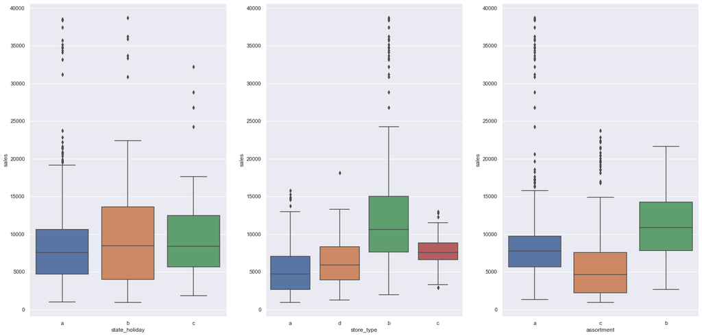

```python
# plot categorical attributes
aux1 = df1[(df1['state_holiday'] != '0') & (df1['sales'] > 0 )]

plt.subplot(1,3,1)
sns.boxplot(x = 'state_holiday', y = 'sales', data = aux1)

plt.subplot(1,3,2)
sns.boxplot(x = 'store_type',y = 'sales', data = aux1)

plt.subplot(1,3,3)
sns.boxplot(x = 'assortment', y = 'sales', data = aux1)
```

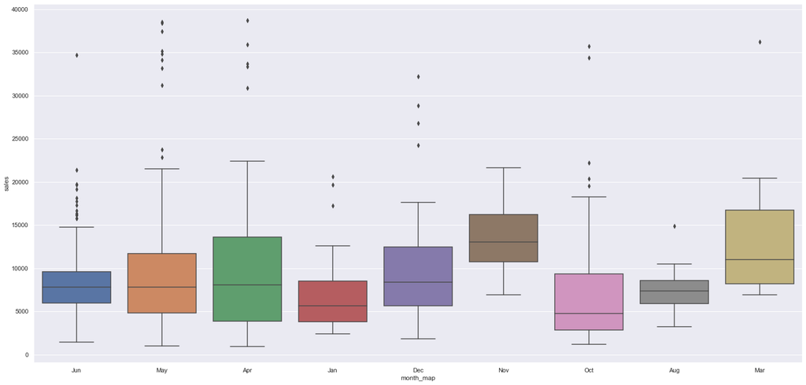

```python
sns.boxplot(x = 'month_map', y = 'sales', data = aux1)
```

# 2.0. FEATURE ENGINEERING

```python
df2 = df1.copy()
```

## 2.1 Hypotheses - Mind Map

[figure not shown]

## 2.2. List of Hypotheses

**1.** Stores with a larger assortment should sell more.

**2.** Stores with closer competitors should sell less.

**3.** Stores with older competitors should sell more.

**4.** Stores with longer running promotions should sell more

**5.** Stores that run more promotions consecutively should sell more.

**6.** Stores open during the Christmas holiday should sell more.

**7.** Stores with larger assortment attract more customers.

**8.** Stores should sell more in the second half of the year.

**9.** Stores should sell more after the 10th of each month.

**10.** Stores should sell less on weekends.

**11.** Stores should sell less during school holidays.

## 2.3. Feature Engineering

```python
# year column
df2['year'] = df2['date'].dt.year

# month column
df2['month'] = df2['date'].dt.month

# day column
df2['day'] = df2['date'].dt.day

# week of year
df2['week_of_year'] = df2['date'].dt.weekofyear

# year and week
df2['year_week'] = df2['date'].dt.strftime( '%Y-%W' )
```

```python
# union of competition_open_since_year + competition_open_since_month in one column
df2['competition_since'] = df2.apply( lambda x: datetime.datetime( year=x['competition_open_since_year'], month=x['competition_open_since_month'],day=1 ), axis=1 )

# time since competitor opening in months
df2['competition_time_month'] = ( ( df2['date'] - df2['competition_since'] )/30 ).apply( lambda x: x.days ).astype( int )

#union of promo2_since_week + promo2_since_year in one column
df2['promo_since'] = df2['promo2_since_year'].astype(str) + '-' + df2['promo2_since_week'].astype(str)
df2['promo_since'] = df2['promo_since'].apply(lambda x: datetime.datetime.strptime(x + '-1', '%Y-%W-%w') - datetime.timedelta(days = 7))

#number of weeks since promo2 started
df2['promo_time_week'] = ((df2['date'] - df2['promo_since'])/7).apply(lambda x: x.days).astype(int)

#transform assortment variable - a = basic, b = extra, c = extended
df2['assortment'] = df2['assortment'].apply(lambda x: 'basic' if x == 'a' else 'extra' if x == 'b' else 'extended')

#transform state_holiday variable - a = public_holiday, b = easter holiday c = christmas
df2['state_holiday'] = df2['state_holiday'].apply(lambda x: 'public_holiday' if x == 'a' else 'easter_holiday' if x == 'b' else 'christmas' if x == 'c' else 'regular_day')
```

```python
df2.head()
```

|  | store | day_of_week | date | sales | customers | open | promo | state_holiday | school_holiday | store_type | ... | is_promo | year | month | day | week_of_year | year_week | competition_since | competition_time_month | promo_since | promo_time_week |
| --- | --- | --- | --- | --- | --- | --- | --- | --- | --- | --- | --- | --- | --- | --- | --- | --- | --- | --- | --- | --- | --- |
| 0 | 1 | 5 | 2015-07-31 | 5263 | 555 | 1 | 1 | regular_day | 1 | c | ... | 0 | 2015 | 7 | 31 | 31 | 2015-30 | 2008-09-01 | 84 | 2015-07-27 | 0 |
| 1 | 2 | 5 | 2015-07-31 | 6064 | 625 | 1 | 1 | regular_day | 1 | a | ... | 1 | 2015 | 7 | 31 | 31 | 2015-30 | 2007-11-01 | 94 | 2010-03-22 | 279 |
| 2 | 3 | 5 | 2015-07-31 | 8314 | 821 | 1 | 1 | regular_day | 1 | a | ... | 1 | 2015 | 7 | 31 | 31 | 2015-30 | 2006-12-01 | 105 | 2011-03-28 | 226 |
| 3 | 4 | 5 | 2015-07-31 | 13995 | 1498 | 1 | 1 | regular_day | 1 | c | ... | 0 | 2015 | 7 | 31 | 31 | 2015-30 | 2009-09-01 | 71 | 2015-07-27 | 0 |
| 4 | 5 | 5 | 2015-07-31 | 4822 | 559 | 1 | 1 | regular_day | 1 | a | ... | 0 | 2015 | 7 | 31 | 31 | 2015-30 | 2015-04-01 | 4 | 2015-07-27 | 0 |

5 rows × 29 columns

# 3.0. DATA FILTERING

```python
df3 = df2.copy()
```

## 3.1. Filtering Rows

```python
#filtering open stores and sales greater than 0
df3 = df3[(df3['open'] != 0) & (df3['sales'] > 0)]
```

## 3.2. Filtering Columns

```python
df3.drop(columns = ['open','promo_interval','month_map'], axis = 1, inplace = True)
df3.columns
```

```
Index(['store', 'day_of_week', 'date', 'sales', 'customers', 'promo',
       'state_holiday', 'school_holiday', 'store_type', 'assortment',
       'competition_distance', 'competition_open_since_month',
       'competition_open_since_year', 'promo2', 'promo2_since_week',
       'promo2_since_year', 'is_promo', 'year', 'month', 'day', 'week_of_year',
       'year_week', 'competition_since', 'competition_time_month',
       'promo_since', 'promo_time_week'],
      dtype='object')
```

# 4.0. EXPLORATORY DATA ANALYSIS

```python
df4 = df3.copy()
```

## 4.1. Univariate Analysis

### 4.1.1. Response Variable

```
The average turnover is: 6955.959133664481
```

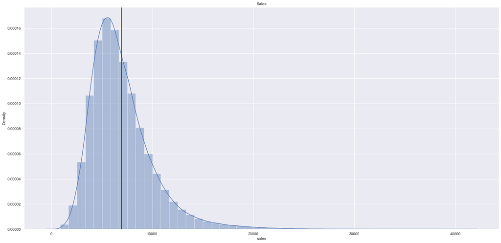

```python
# Sales mean and distribution

sales_mean=df4['sales'].mean()
print("The average turnover is: {}".format(sales_mean))

sns.distplot(df4['sales'])
plt.axvline(x=sales_mean, color='blue')
plt.title("Sales")
```

### 4.1.2. Numerical Variables

```
array([[<AxesSubplot:title={'center':'store'}>,
        <AxesSubplot:title={'center':'day_of_week'}>,
        <AxesSubplot:title={'center':'sales'}>,
        <AxesSubplot:title={'center':'customers'}>],
       [<AxesSubplot:title={'center':'promo'}>,
        <AxesSubplot:title={'center':'school_holiday'}>,
        <AxesSubplot:title={'center':'competition_open_since_month'}>,
        <AxesSubplot:title={'center':'competition_open_since_year'}>],
       [<AxesSubplot:title={'center':'promo2'}>,
        <AxesSubplot:title={'center':'promo2_since_week'}>,
        <AxesSubplot:title={'center':'promo2_since_year'}>,
        <AxesSubplot:title={'center':'is_promo'}>],
       [<AxesSubplot:title={'center':'year'}>,
        <AxesSubplot:title={'center':'month'}>,
        <AxesSubplot:title={'center':'day'}>,
        <AxesSubplot:title={'center':'week_of_year'}>]], dtype=object)
```

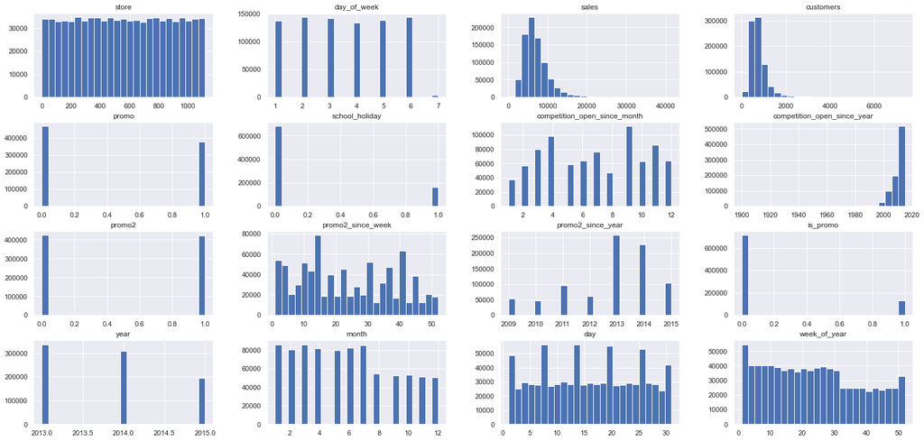

```python
# Plot numerical variables individually
num_attributes2 = df4.select_dtypes(include = 'int64')
num_attributes2.hist(bins = 25)
```

### 4.1.3. Categorical Variable

```python
#select categorical variables
df4.select_dtypes(include = 'object').columns
```

```
Index(['state_holiday', 'store_type', 'assortment', 'year_week'], dtype='object')
```

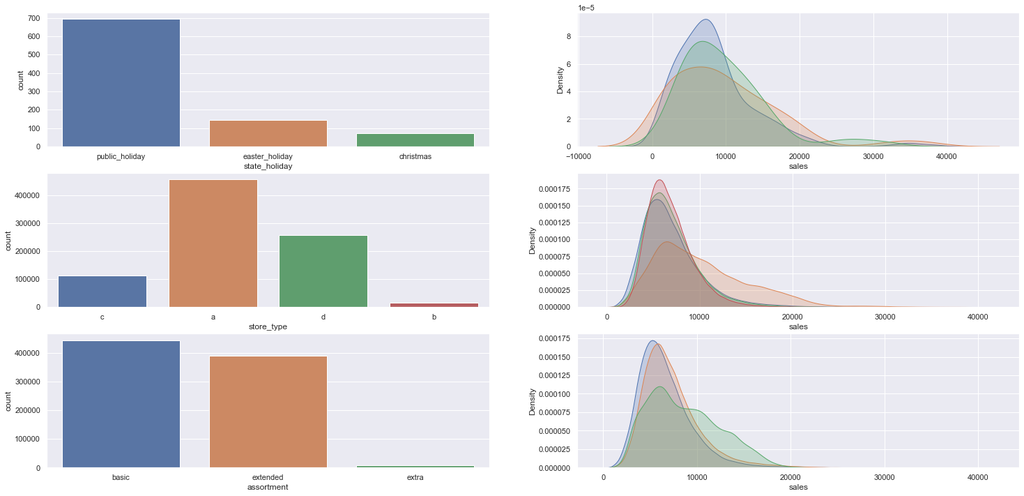

```python
# Plot categorical variables

#state_holiday
a = df4[df4['state_holiday'] != 'regular_day']
plt.subplot(3,2,1)
sns.countplot(a['state_holiday'])

plt.subplot(3,2,2)
sns.kdeplot(df4[df4['state_holiday'] == 'public_holiday']['sales'],label = 'public_holiday',shade = True)
sns.kdeplot(df4[df4['state_holiday'] == 'easter_holiday']['sales'],label = 'easter_holiday',shade = True)
sns.kdeplot(df4[df4['state_holiday'] == 'christmas']['sales'],label = 'christmas',shade = True)

#store_type
plt.subplot(3,2,4)
sns.kdeplot(df4[df4['store_type'] == 'a']['sales'],label = 'a',shade = True)
sns.kdeplot(df4[df4['store_type'] == 'b']['sales'],label = 'b',shade = True)
sns.kdeplot(df4[df4['store_type'] == 'c']['sales'],label = 'c',shade = True)
sns.kdeplot(df4[df4['store_type'] == 'd']['sales'],label = 'd',shade = True)

plt.subplot(3,2,3)
sns.countplot(df4['store_type'])

#assortment
plt.subplot(3,2,5)
sns.countplot(df4['assortment'])

plt.subplot(3,2,6)
sns.kdeplot(df4[df4['assortment'] == 'basic']['sales'], label  = 'basic', shade = True)
sns.kdeplot(df4[df4['assortment'] == 'extended']['sales'], label = 'extended', shade = True)
sns.kdeplot(df4[df4['assortment'] == 'extra']['sales'], label = 'extra', shade = True)
```

## 4.2. Bivariate Analysis

### H1. Stores with a larger assortment sell more

**True** - Stores with a larger assortment sell more, but represent a smaller volume of sales in the grand total.

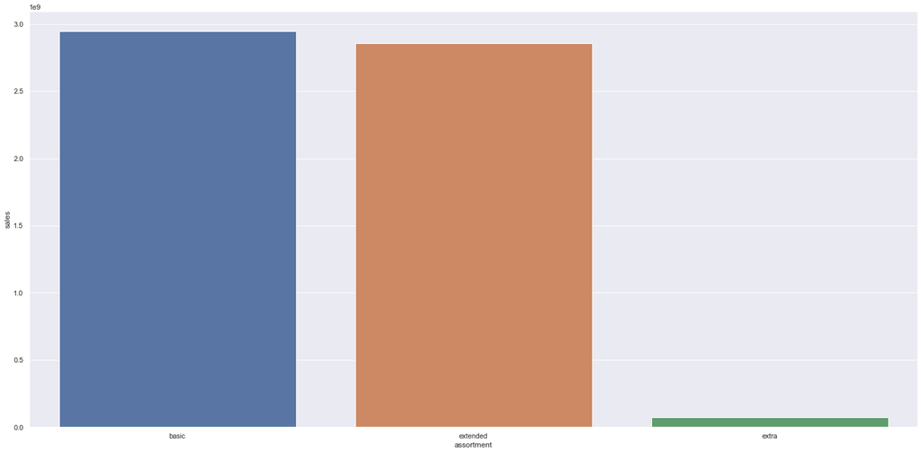

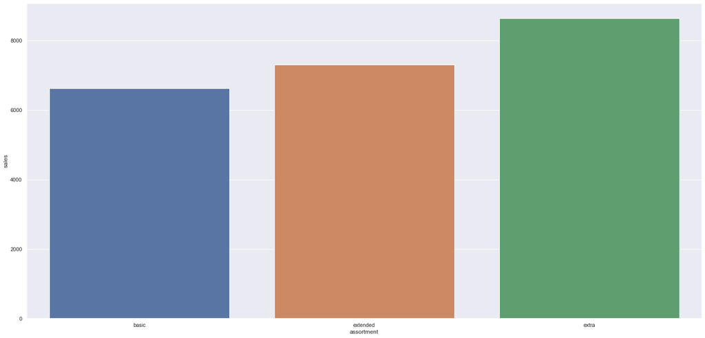

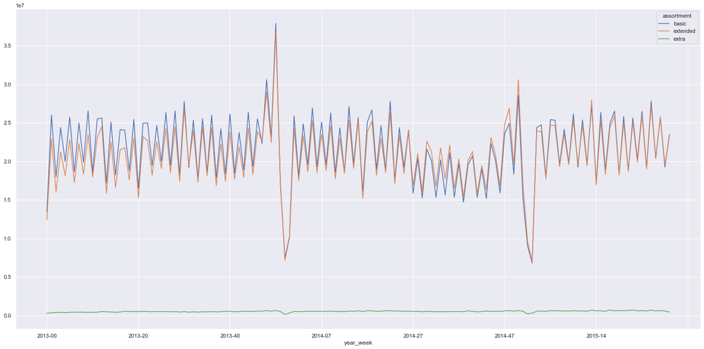

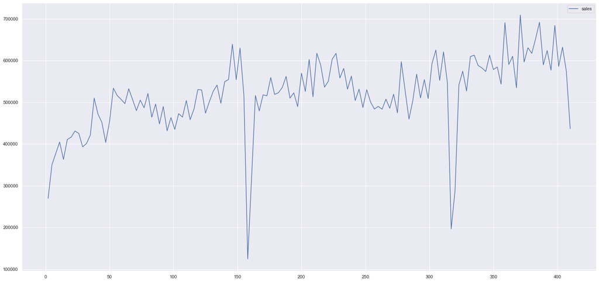

```python
#total sales amount by store type
aux0 = df4[['assortment','sales']].groupby('assortment').sum().reset_index()
sns.barplot(x = 'assortment', y = 'sales', data = aux0);
plt.show()

#average sales by store type
aux1 = df4[['assortment','sales']].groupby('assortment').mean().reset_index()
sns.barplot(x = 'assortment', y = 'sales', data = aux1);
plt.show()

#variation in sales over time
aux2 = df4[['assortment','sales','year_week']].groupby(['year_week','assortment']).sum().reset_index()
aux3 = aux2.pivot(index = 'year_week', columns = 'assortment', values = 'sales')
aux3.plot()

#zoom - extra type
aux4 = aux2[aux2['assortment'] == 'extra']
aux4.pivot(index = 'year_week',columns = 'assortment', values = 'sales')
aux4.plot()
```

### **H2**. Stores with closer competitors sell less

**False** - Stores with closer competitors sell more.

[output not shown]

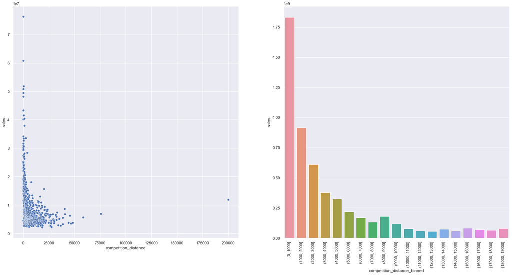

```python
#sales by competition distance
plt.subplot(1,2,1)
aux1 = df4[['competition_distance','sales']].groupby('competition_distance').sum().reset_index()
sns.scatterplot(x = 'competition_distance', y = 'sales', data = aux1);

plt.subplot(1,2,2)
bins = list(np.arange(0,20000,1000))
aux1['competition_distance_binned'] = pd.cut(aux1['competition_distance'], bins = bins)
aux2 = aux1[['competition_distance_binned','sales']].groupby('competition_distance_binned').sum().reset_index()
sns.barplot(x = 'competition_distance_binned', y = 'sales', data = aux2);
plt.xticks(rotation = 90)
```

```python
aux1.corr(method = 'pearson')
```

|  | competition_distance | sales |
| --- | --- | --- |
| competition_distance | 1.000000 | -0.229415 |
| sales | -0.229415 | 1.000000 |

### H3. Stores with older competitors sell more

**False** - Stores with older competitors sell less.

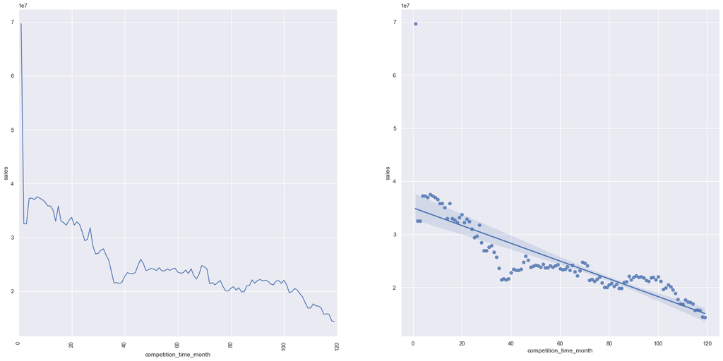

```python
# competition x sales

plt.subplot(1,2,1)
aux1 = df4[['competition_time_month','sales']].groupby('competition_time_month').sum().reset_index()
aux2 = aux1[(aux1['competition_time_month'] < 120) & (aux1['competition_time_month'] > 0 )]
sns.lineplot(x = 'competition_time_month', y = 'sales', data = aux2);
plt.xlim(0, 120)
plt.xticks(rotation = 90)

plt.subplot(1,2,2)
sns.regplot(x = 'competition_time_month', y = 'sales', data = aux2);
```

```python
aux1.corr(method = 'pearson')
```

|  | competition_time_month | sales |
| --- | --- | --- |
| competition_time_month | 1.00000 | -0.10142 |
| sales | -0.10142 | 1.00000 |

### H4. Stores with longer running promotions sell more

**False** - Promotion time doesn't affect sales and stores with longer running promotions tend to sell less after a certain duration.

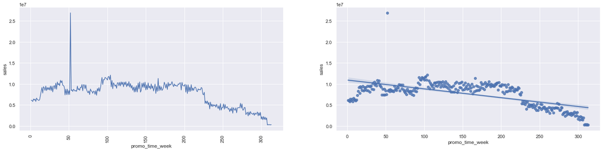

```python
aux1 = df4[['promo_time_week','sales']].groupby('promo_time_week').sum().reset_index()

plt.subplot(2,2,1)
aux2 = aux1[aux1['promo_time_week']>0]
sns.lineplot(x = 'promo_time_week',y = 'sales', data = aux2);
plt.xticks(rotation = 90);

plt.subplot(2,2,2)
sns.regplot(x = 'promo_time_week',y = 'sales', data = aux2);
```

```python
aux1.corr(method = 'pearson')
```

|  | promo_time_week | sales |
| --- | --- | --- |
| promo_time_week | 1.000000 | -0.029445 |
| sales | -0.029445 | 1.000000 |

### H5. Stores that run more promotions consecutively sell more

**False** - Stores that with extended periods of promotions sell less.

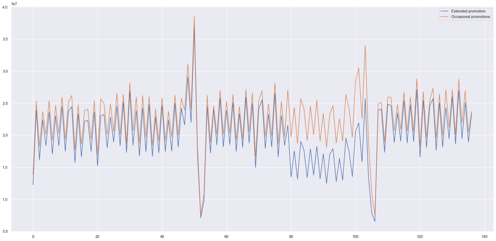

```python
aux1 = df4[(df4['promo2'] == 1)][['year_week','sales']].groupby('year_week').sum().reset_index()
ax = aux1.plot()

aux2 = df4[(df4['promo2'] == 0)][['year_week','sales']].groupby('year_week').sum().reset_index()
aux2.plot(ax = ax)
ax.legend(labels = ['Extended promotion','Occasional promotions' ])
```

### H6. Stores open during the Christmas holiday sell more

**True** - Stores open during the Christmas holiday sell more than a regular day.

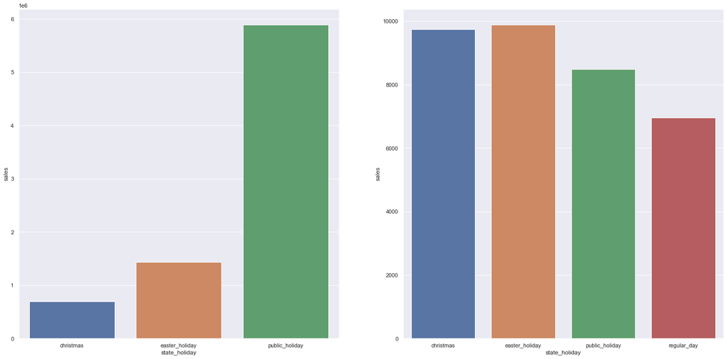

```python
#Sales during holidays
aux0 = df4[['state_holiday','sales']].groupby('state_holiday').sum().reset_index()

plt.subplot(1,2,1)
aux1 = aux0[aux0['state_holiday'] != 'regular_day']
sns.barplot(x = 'state_holiday', y = 'sales', data = aux1)

#average sales on holidays
plt.subplot(1,2,2)
aux2 = df4[['state_holiday','sales']].groupby('state_holiday').mean().reset_index()
sns.barplot(x = 'state_holiday', y = 'sales', data = aux2)
```

### H7. Stores with larger assortment attract more customers

**True** - Stores with larger assortment attract more customers.

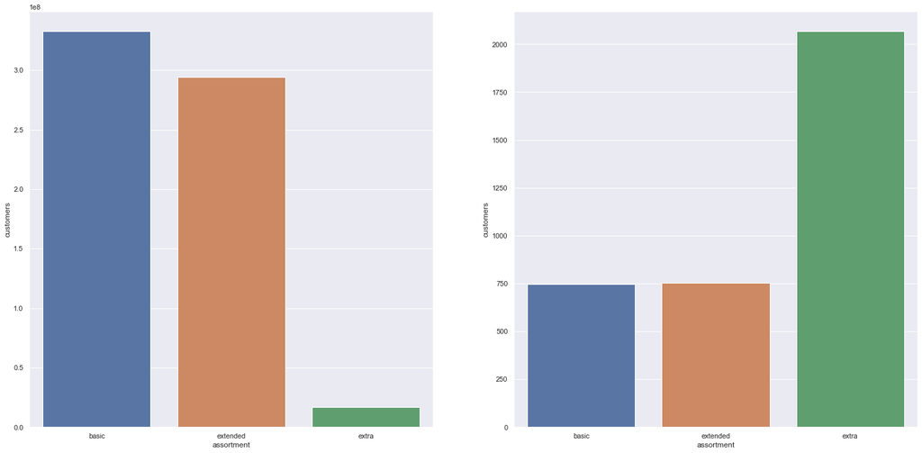

```python
# sales since store opening
plt.subplot(1,2,1)
aux1 = df4[['customers','assortment']].groupby('assortment').sum().reset_index()
sns.barplot(x = 'assortment',y = 'customers', data = aux1)

plt.subplot(1,2,2)
aux2 = df4[['customers','assortment']].groupby('assortment').mean().reset_index()
sns.barplot(x = 'assortment',y = 'customers', data = aux2)
```

### H8. Stores sell more in the second half of the year

**False** - Stores sell less in the second half of the year.

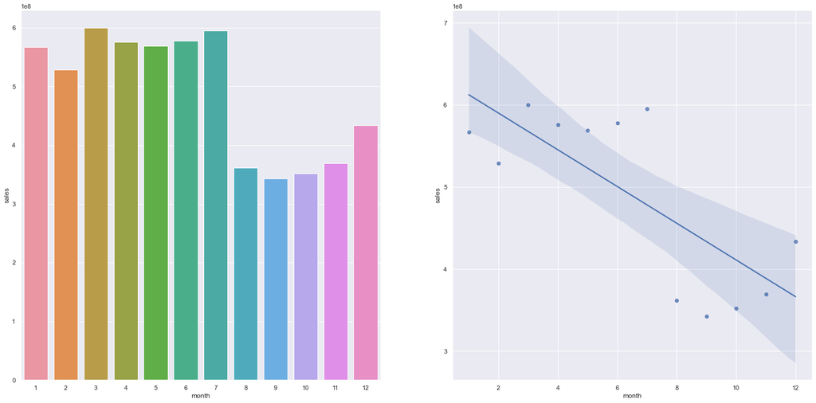

```python
# sales during the year
aux1 = df4[['month','sales']].groupby('month').sum().reset_index()

plt.subplot(1,2,1)
sns.barplot(x = 'month',y = 'sales', data = aux1)

plt.subplot(1,2,2)
sns.regplot(x = 'month',y = 'sales', data = aux1)
```

```python
aux1.corr(method = 'pearson')
```

|  | month | sales |
| --- | --- | --- |
| month | 1.000000 | -0.751711 |
| sales | -0.751711 | 1.000000 |

### H9. Stores sell more after the 10th of each month

In average, stores sell more before the 10th of each month. However, there is a considerable increase in the number of sales after the 10th of each month.

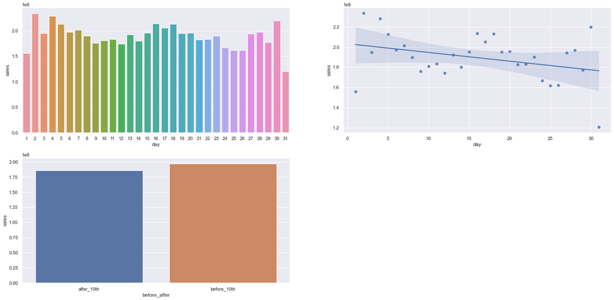

```python
#sales during the month
aux1 = df4[['day','sales']].groupby('day').sum().reset_index()

plt.subplot(2,2,1)
sns.barplot(x = 'day',y = 'sales', data = aux1)

plt.subplot(2,2,2)
sns.regplot(x = 'day',y = 'sales', data = aux1)

plt.subplot(2,2,3)
aux1['before_after'] = aux1['day'].apply(lambda x:'before_10th' if x <= 10 else 'after_10th')
aux2 = aux1[['before_after','sales']].groupby('before_after').mean().reset_index()
sns.barplot(x = 'before_after', y = 'sales', data = aux2)
```

```python
aux1.corr(method = 'pearson')
```

|  | day | sales |
| --- | --- | --- |
| day | 1.00000 | -0.34602 |
| sales | -0.34602 | 1.00000 |

### H10. Stores sell less on weekends

**True** - Stores sell less on weekends.

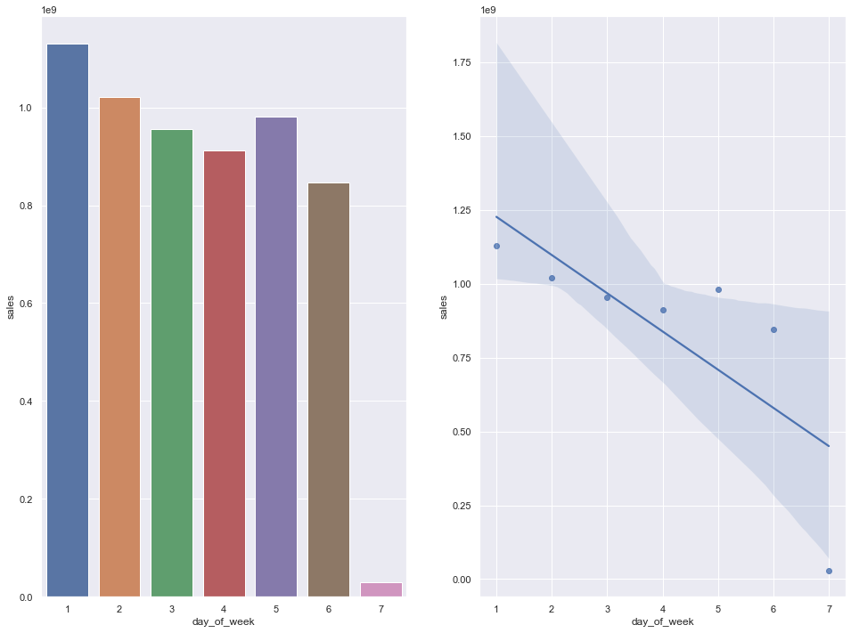

```python
#sales during the week
aux1 = df4[['day_of_week','sales']].groupby('day_of_week').sum().reset_index()

plt.subplot(1,3,1)
sns.barplot(x = 'day_of_week',y = 'sales', data = aux1)

plt.subplot(1,3,2)
sns.regplot(x = 'day_of_week',y = 'sales', data = aux1)
```

```python
aux1.corr(method = 'pearson')
```

|  | day_of_week | sales |
| --- | --- | --- |
| day_of_week | 1.000000 | -0.760303 |
| sales | -0.760303 | 1.000000 |

### H11. Stores sell less during school holidays

**False** - Stores sell more during school holidays.

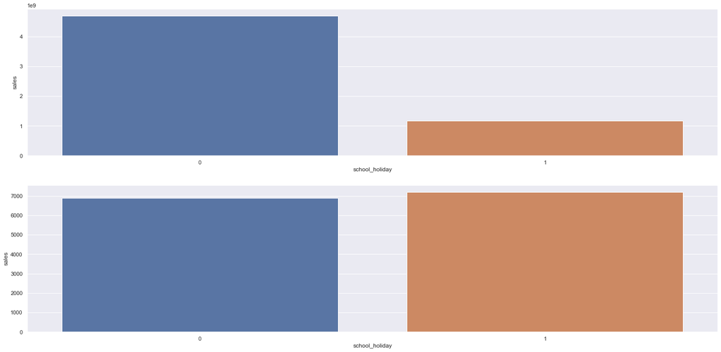

```python
#total of sales during the year - school holidays x regular days
plt.subplot(2,1,1)
aux0 = df4[['school_holiday','sales']].groupby('school_holiday').sum().reset_index()
sns.barplot(x = 'school_holiday',y = 'sales', data = aux0)

#average sales in a school holiday x regular day
plt.subplot(2,1,2)
aux1 = df4[['school_holiday','sales']].groupby('school_holiday').mean().reset_index()
sns.barplot(x = 'school_holiday',y = 'sales', data = aux1)
```

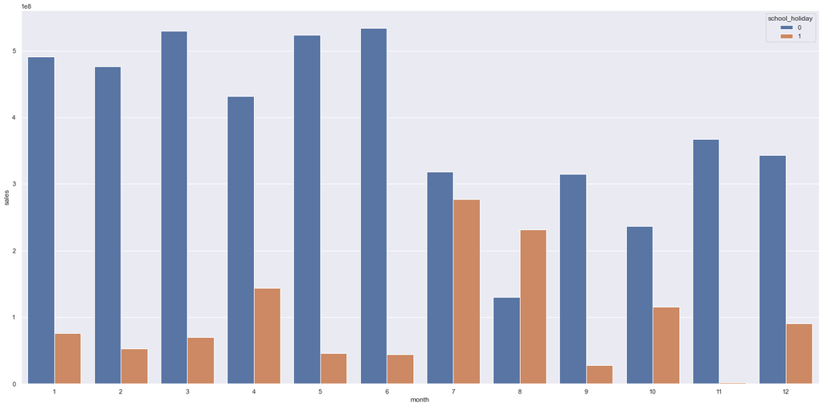

```python
#total amount of sales in school holidays x regular days

aux2 = df4[['month','school_holiday','sales']].groupby(['month','school_holiday']).sum().reset_index()
sns.barplot(x = 'month',y = 'sales',hue = 'school_holiday', data = aux2)
```

## 4.3. Multivariate Analysis

### 4.3.1. Numerical Attributes

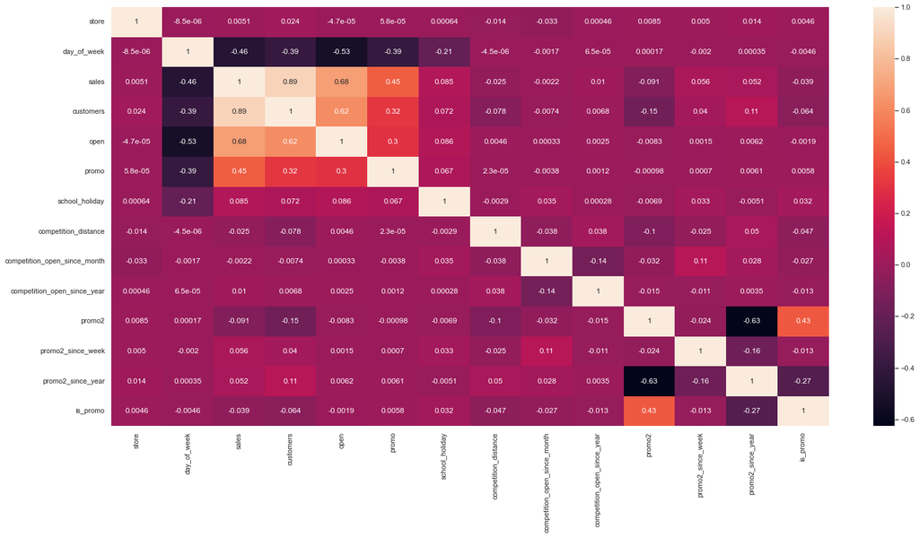

```python
#separating numerical variables and building the heat map

correlation = num_attributes.corr(method = 'pearson')
sns.heatmap(correlation, annot = True)
```

### 4.3.2. Categorical Attributes

```python
#only categorical data
a = df4.select_dtypes(include = 'object')
a.head()
```

|  | state_holiday | store_type | assortment | year_week |
| --- | --- | --- | --- | --- |
| 0 | regular_day | c | basic | 2015-30 |
| 1 | regular_day | a | basic | 2015-30 |
| 2 | regular_day | a | basic | 2015-30 |
| 3 | regular_day | c | extended | 2015-30 |
| 4 | regular_day | a | basic | 2015-30 |

cramer_v: **The construction of this function was developed in the "Helper Functions" section**

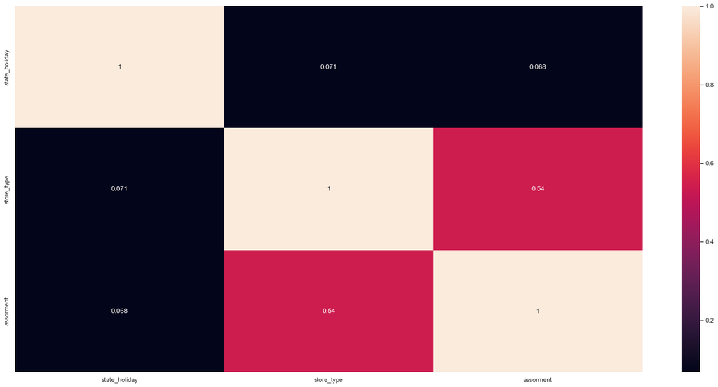

```python
#calculate cramer v correlation - pairs
a1 = cramer_v(a['state_holiday'],a['state_holiday'])
a2 = cramer_v(a['state_holiday'],a['store_type'])
a3 = cramer_v(a['state_holiday'],a['assortment'])

a4 = cramer_v(a['store_type'],a['state_holiday'])
a5 = cramer_v(a['store_type'],a['store_type'])
a6 = cramer_v(a['store_type'],a['assortment'])

a7 = cramer_v(a['assortment'],a['state_holiday'])
a8 = cramer_v(a['assortment'],a['store_type'])
a9 = cramer_v(a['assortment'],a['assortment'])

# create a dataframe with all the corr values
d = pd.DataFrame({'state_holiday': [a1,a2,a3],
              'store_type': [a4,a5,a6],
              'assorment': [a7,a8,a9]
             })
d = d.set_index(d.columns)

#correlation heatmap
sns.heatmap(d , annot = True)
```

# 5.0. DATA PREPARATION

```python
df5 = df4.copy()
```

## 5.1. Rescaling

```python
#selecting numerical features
num_feat = df5.select_dtypes(include = ['int64','float64'])
num_feat.head()
```

|  | store | day_of_week | sales | customers | promo | school_holiday | competition_distance | competition_open_since_month | competition_open_since_year | promo2 | promo2_since_week | promo2_since_year | is_promo | year | month | day | week_of_year |
| --- | --- | --- | --- | --- | --- | --- | --- | --- | --- | --- | --- | --- | --- | --- | --- | --- | --- |
| 0 | 1 | 5 | 5263 | 555 | 1 | 1 | 1270.0 | 9 | 2008 | 0 | 31 | 2015 | 0 | 2015 | 7 | 31 | 31 |
| 1 | 2 | 5 | 6064 | 625 | 1 | 1 | 570.0 | 11 | 2007 | 1 | 13 | 2010 | 1 | 2015 | 7 | 31 | 31 |
| 2 | 3 | 5 | 8314 | 821 | 1 | 1 | 14130.0 | 12 | 2006 | 1 | 14 | 2011 | 1 | 2015 | 7 | 31 | 31 |
| 3 | 4 | 5 | 13995 | 1498 | 1 | 1 | 620.0 | 9 | 2009 | 0 | 31 | 2015 | 0 | 2015 | 7 | 31 | 31 |
| 4 | 5 | 5 | 4822 | 559 | 1 | 1 | 29910.0 | 4 | 2015 | 0 | 31 | 2015 | 0 | 2015 | 7 | 31 | 31 |

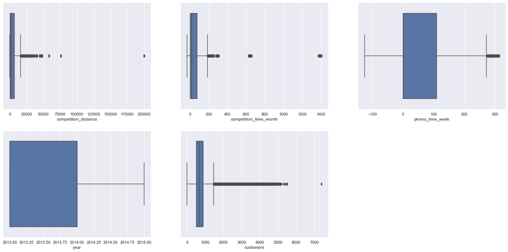

```python
#boxplots
plt.subplot(2,3,1)
sns.boxplot(df5['competition_distance'])

plt.subplot(2,3,2)
sns.boxplot(df5['competition_time_month'])

plt.subplot(2,3,3)
sns.boxplot(df5['promo_time_week'])

plt.subplot(2,3,4)
sns.boxplot(df5['year'])

plt.subplot(2,3,5)
sns.boxplot(df5['customers'])
```

Variables with too many outliers - RobustScaler:

- competition_distance
- competition_time_month
- customers

Variables with few or no outliers - MinMaxScaler:

- promo_time_week
- year

```python
rs = RobustScaler()
mms = MinMaxScaler()

#competition_distance - RobustScaler
df5['competition_distance'] = rs.fit_transform(df5[['competition_distance']].values)

#competition_time_month - RobustScaler
df5['competition_time_month'] = rs.fit_transform(df5[['competition_time_month']].values)

#competition_time_month - RobustScaler
df5['customers'] = rs.fit_transform(df5[['customers']].values)

#year - MinMaxScaler
df5['year'] = mms.fit_transform(df5[['year']].values)

#promo_time_week - MinMaxScaler
df5['promo_time_week'] = mms.fit_transform(df5[['promo_time_week']].values)
```

## 5.3. Transformation

### 5.3.1. Response Variable - Log Transformation

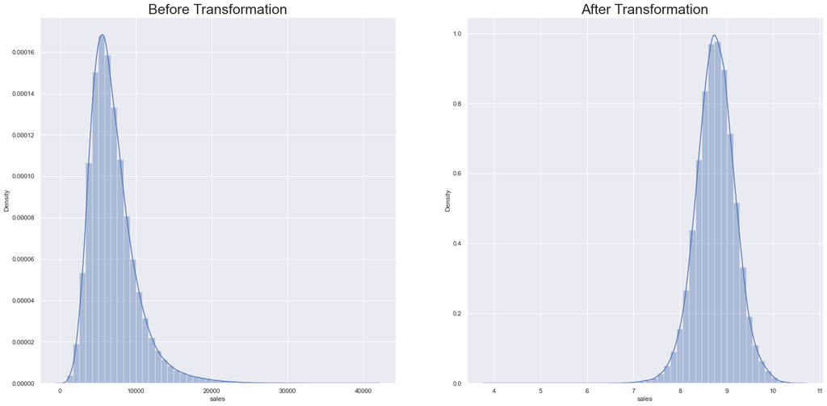

```python
plt.subplot(1,2,1)
sns.distplot(df5['sales'])
plt.title('Before Transformation', fontsize = 25)

plt.subplot(1,2,2)
sns.distplot(np.log1p(df5['sales']))
plt.title("After Transformation", fontsize = 25)

#logarithmic transformation
df5['sales'] = np.log1p(df5['sales'])
```

### 5.3.2. Encoding

- OneHotEncoder - presence 1/ absence 0
- LabelEncoder - independent numeric values (1,2,3)
- OrdinalEncoder - sequence of hierarchical labels (1 < 2 < 3)

```python
#store_type - LabelEncoder
le = LabelEncoder()
df5['store_type'] = le.fit_transform(df5['store_type'])

#assortment - OrdinalEncoder
assortment_dict = {'basic': 1,
                   'extra': 2,
                   'extended': 3}
df5['assortment'] = df5['assortment'].map(assortment_dict)

#state_holiday - OneHotEncoder
df5 = pd.get_dummies(df5, prefix = ['state_holiday'], columns = ['state_holiday'])
```

### 5.3.3. Nature Transformation

Encoding cyclical features - sine and cosine transformation

```python
#month
df5['month_sin'] = df5['month'].apply(lambda x: np.sin(x * (2* np.pi/12) ))
df5['month_cos'] = df5['month'].apply(lambda x: np.cos(x * (2* np.pi/12) ))

#day
df5['day_sin'] = df5['day'].apply(lambda x: np.sin(x * (2* np.pi/30) ))
df5['day_cos'] = df5['day'].apply(lambda x: np.cos(x * (2* np.pi/30) ))

#week_of_year
df5['week_of_year_sin'] = df5['week_of_year'].apply(lambda x: np.sin(x * (2* np.pi/52) ))
df5['week_of_year_cos'] = df5['week_of_year'].apply(lambda x: np.cos(x * (2* np.pi/52) ))

#day_of_week
df5['day_of_week_sin'] = df5['day_of_week'].apply(lambda x: np.sin(x * (2* np.pi/7) ))
df5['day_of_week_cos'] = df5['day_of_week'].apply(lambda x: np.cos(x * (2* np.pi/7) ))
```

# 6.0. FEATURE SELECTION

```python
df6 = df5.copy()
```

```python
#delete the columns that were used to construct other variables
cols_drop = ['month','week_of_year','day','day_of_week','promo_since','competition_since','year_week']
df6 = df6.drop(cols_drop,axis = 1)
```

## 6.1. Split dataframe into training and test dataset

- Test: contain data from the last six weeks
- Training: contain the entire dataset except the last six weeks

```python
#setting the period of six weeks
df6[['date','store']].groupby('store').max().reset_index()['date'][0] - datetime.timedelta(days = 7*6)
```

```
Timestamp('2015-06-19 00:00:00')
```

```python
#defining the training dataset
X_train = df6[df6['date'] < '2015-06-19']
y_train = X_train['sales']

#defining the test dataset
X_test = df6[df6['date'] > '2015-06-19']
y_test = X_test['sales']


print("Training min date: {}".format(X_train['date'].min()))
print("Training max date: {}".format(X_train['date'].max()))
print('\n')
print("Test Min date: {}".format(X_test['date'].min()))
print("Test Max Date: {}".format(X_test['date'].max()))
```

```
Training min date: 2013-01-01 00:00:00
Training max date: 2015-06-18 00:00:00


Test Min date: 2015-06-20 00:00:00
Test Max Date: 2015-07-31 00:00:00
```

## 6.2. Boruta as Feature Selector

### 6.2.1. Best features from boruta

```python
#training and test dataset for boruta - ravel: transforms into continuous flattered array
X_train_n = X_train.drop(['date','sales'], axis = 1).values
y_train_n = y_train.values.ravel()

#define RandomForestRegressor - n_jobs= -1 : parallel processing
rf = RandomForestRegressor(n_jobs = -1)

#define boruta - verbose: verbosity level, random_state: seed
boruta = BorutaPy(rf, n_estimators = 'auto', verbose = 2, random_state = 42).fit(X_train_n,y_train_n)
```

```
Iteration: 	1 / 100
Confirmed: 	0
Tentative: 	28
Rejected: 	0
Iteration: 	2 / 100
Confirmed: 	0
Tentative: 	28
Rejected: 	0
Iteration: 	3 / 100
Confirmed: 	0
Tentative: 	28
Rejected: 	0
Iteration: 	4 / 100
Confirmed: 	0
Tentative: 	28
Rejected: 	0
Iteration: 	5 / 100
Confirmed: 	0
Tentative: 	28
Rejected: 	0
Iteration: 	6 / 100
Confirmed: 	0
Tentative: 	28
Rejected: 	0
Iteration: 	7 / 100
Confirmed: 	0
Tentative: 	28
Rejected: 	0
Iteration: 	8 / 100
Confirmed: 	18
Tentative: 	0
Rejected: 	10


BorutaPy finished running.

Iteration: 	9 / 100
Confirmed: 	18
Tentative: 	0
Rejected: 	10
```

```python
# selected features - only confirmed ones are True
cols_selected = boruta.support_.tolist()
print(cols_selected)
```

```
[True, True, True, False, True, True, True, True, True, True, True, True, False, False, True, True, False, False, False, False, False, True, False, True, False, True, True, True]
```

```python
# model with best features
X_train_fs = X_train.drop(['date','sales'], axis = 1)
cols_selected_boruta = X_train_fs.iloc[:, cols_selected].columns.to_list()

#not selected boruta
cols_not_selected_boruta = np.setdiff1d(X_train_fs.columns, cols_selected_boruta)

#print variables
print(cols_selected_boruta)
print('\n')
print(cols_not_selected_boruta)
```

[output not shown]

## 6.3. Manual Feature Selection

Although the algorithm automatically selects the most important variables, we chose to add "month_sin", "week_of_year_sin" and "day_sin" to the model. We also chose to remove the 'customers' variable because we can't predict the future number os customers.

```python
# add "month_sin", "week_of_year_sin" and "day_of_week_sin"

cols_selected_boruta = ['store',
                        'promo',
                        'store_type',
                        'assortment',
                        'competition_distance',
                        'competition_open_since_month',
                        'competition_open_since_year',
                        'promo2','promo2_since_week',
                        'promo2_since_year',
                        'competition_time_month',
                        'promo_time_week',
                        'month_cos',
                        'day_cos',
                        'week_of_year_cos',
                        'day_of_week_sin',
                        'day_of_week_cos',
                        'month_sin',
                        'day_sin',
                        'week_of_year_sin']

#Full Columns - add date and sales
cols_selected_boruta_full = ['store',
                        'promo',
                        'store_type',
                        'assortment',
                        'competition_distance',
                        'competition_open_since_month',
                        'competition_open_since_year',
                        'promo2','promo2_since_week',
                        'promo2_since_year',
                        'competition_time_month',
                        'promo_time_week',
                        'month_cos',
                        'day_cos',
                        'week_of_year_cos',
                        'day_of_week_sin',
                        'day_of_week_cos',
                        'month_sin',
                        'day_sin',
                        'week_of_year_sin',
                        'date',
                        'sales']
```

# 7.0. MACHINE LEARNING MODELLING

- Average Model
- Linear Regression
- Lasso Regression
- Random Forest Regressor
- XGBoost Regressor

```python
# define new train and test datasets
x_train = X_train[cols_selected_boruta]
x_test = X_test[cols_selected_boruta]

# train set to Time Series Data Preparation (include date and sales)
x_train_ts = X_train[cols_selected_boruta_full]
```

## 7.1. Average Model

The average model is the basis for comparing the performance of the following ML models.

ml_error - define mae, mape and rmse errors. </br> **The construction of this function was developed in the "Helper Functions" section**.

```python
#defining dataset
aux1 = x_test.copy()
aux1['sales'] = y_test.copy()

#prediction - rearrange and add sales column as predictions
aux2 = aux1[['store','sales']].groupby("store").mean().reset_index().rename(columns = {'sales':'predictions'})
aux1 = pd.merge(aux1,aux2, how = 'left', on = 'store')

#define predictions variable
yhat_baseline = aux1['predictions']

#performance - real values x predicted values
#sales variable was transformed to the original values
baseline_result = ml_error("Average Model", np.expm1(y_test), np.expm1(yhat_baseline))
baseline_result
```

|  | Model Name | MAE | MAPE | RMSE |
| --- | --- | --- | --- | --- |
| 0 | Average Model | 1366.128351 | 0.452087 | 1854.263316 |

## 7.2. Linear Regression Model

Checking if the dataset is linear.

```python
#regression model
lr = LinearRegression().fit(x_train,y_train)

#values prediction
yhat_lr = lr.predict(x_test)

#performance - real values x predicted values
lr_result = ml_error('Linear Regression',np.expm1(y_test),np.expm1(yhat_lr))
lr_result
```

|  | Model Name | MAE | MAPE | RMSE |
| --- | --- | --- | --- | --- |
| 0 | Linear Regression | 1868.73952 | 0.293745 | 2675.947846 |

### 7.2.1. Linear Regression Model - Cross Validation

cross_validation - **The construction of this function was developed in the "Helper Functions" section**.

```python
#applying cross validation with 5 kfolds
lr_result_cv = cross_validation( x_train_ts, 5, 'Linear Regression', lr, verbose=False )
lr_result_cv
```

|  | Model Name | MAE CV | MAPE CV | RMSE CV |
| --- | --- | --- | --- | --- |
| 0 | Linear Regression | 2081.73 +/- 295.63 | 0.3 +/- 0.02 | 2952.52 +/- 468.37 |

## 7.3. Linear Regression Regularized Model - Lasso

```python
#lasso model - alpha: weight
lrr = Lasso(alpha = 0.01).fit(x_train,y_train)

#values prediction
yhat_lrr = lrr.predict(x_test)

#performance - real values x predicted values
lrr_result = ml_error('Lasso Regression',np.expm1(y_test),np.expm1(yhat_lrr))
lrr_result
```

|  | Model Name | MAE | MAPE | RMSE |
| --- | --- | --- | --- | --- |
| 0 | Lasso Regression | 1894.132076 | 0.290168 | 2750.818675 |

### 7.3.1. Lasso Regression - Cross Validation

```python
#applying cross validation
lrr_result_cv = cross_validation( x_train_ts, 5, 'Lasso Regression', lrr, verbose=False )
lrr_result_cv
```

|  | Model Name | MAE CV | MAPE CV | RMSE CV |
| --- | --- | --- | --- | --- |
| 0 | Lasso Regression | 2116.38 +/- 341.5 | 0.29 +/- 0.01 | 3057.75 +/- 504.26 |

## 7.4. Random Forest Regressor

```python
#random forest model - n_estimators:number of trees
rf = RandomForestRegressor(n_estimators = 100, n_jobs = -1, random_state = 42).fit(x_train,y_train)

#values prediction
yhat_rf = rf.predict(x_test)

#performance - real values x predicted values
rf_result = ml_error('Random Forest Regressor',np.expm1(y_test),np.expm1(yhat_rf))
rf_result
```

|  | Model Name | MAE | MAPE | RMSE |
| --- | --- | --- | --- | --- |
| 0 | Random Forest Regressor | 677.68693 | 0.099926 | 1010.478534 |

### 7.4.1.Random Forest - Cross Validation

```python
#applying cross validation
rf_result_cv = cross_validation( x_train_ts, 5, 'Random Forest Regressor', rf, verbose=True )
rf_result_cv
```

```
KFold Number: 5

KFold Number: 4

KFold Number: 3

KFold Number: 2

KFold Number: 1
```

|  | Model Name | MAE CV | MAPE CV | RMSE CV |
| --- | --- | --- | --- | --- |
| 0 | Random Forest Regressor | 839.0 +/- 219.99 | 0.12 +/- 0.02 | 1259.08 +/- 321.81 |

## 7.5. XGBoost Regressor

```python
# xgboost model
model_xgb = xgb.XGBRegressor( objective='reg:squarederror', #regression with squared loss
                              n_estimators=100, #number of trees
                              eta=0.01, #learning rate
                              max_depth=10, #maximum tree depth
                              subsample=0.7, #randomly sample 70% of the training data
                              colsample_bytee=0.9 ).fit( x_train, y_train ) #Subsampling 90% of the variables for every tree constructed

# values prediction
yhat_xgb = model_xgb.predict( x_test )

# performance - real values x predicted values
xgb_result = ml_error( 'XGBoost Regressor', np.expm1( y_test ), np.expm1( yhat_xgb ) )
xgb_result
```

[output not shown]

|  | Model Name | MAE | MAPE | RMSE |
| --- | --- | --- | --- | --- |
| 0 | XGBoost Regressor | 6667.598356 | 0.949421 | 7320.386882 |

### 7.5.1 XGBoost Regressor - Cross Validation

```python
#applying cross validation
xgb_result_cv = cross_validation( x_train_ts, 5, 'XGBoost Regressor', model_xgb, verbose=True )
xgb_result_cv
```

[output not shown]

|  | Model Name | MAE CV | MAPE CV | RMSE CV |
| --- | --- | --- | --- | --- |
| 0 | XGBoost Regressor | 7047.92 +/- 587.56 | 0.95 +/- 0.0 | 7713.98 +/- 688.63 |

## 7.6. Compare Model Performance

### 7.6.1. Single Performance

```python
#create error table and sort by RMSE
modelling_result = pd.concat( [baseline_result, lr_result, lrr_result, rf_result, xgb_result] )
modelling_result.sort_values( 'RMSE' )
```

|  | Model Name | MAE | MAPE | RMSE |
| --- | --- | --- | --- | --- |
| 0 | Random Forest Regressor | 677.686930 | 0.099926 | 1010.478534 |
| 0 | Average Model | 1366.128351 | 0.452087 | 1854.263316 |
| 0 | Linear Regression | 1868.739520 | 0.293745 | 2675.947846 |
| 0 | Lasso Regression | 1894.132076 | 0.290168 | 2750.818675 |
| 0 | XGBoost Regressor | 6667.598356 | 0.949421 | 7320.386882 |

### 7.6.2. Real Performance - Cross Validation

```python
#compare errors after cross validation
modelling_result_cv = pd.concat( [lr_result_cv, lrr_result_cv, rf_result_cv, xgb_result_cv] )
modelling_result_cv.sort_values("RMSE CV")
```

|  | Model Name | MAE CV | MAPE CV | RMSE CV |
| --- | --- | --- | --- | --- |
| 0 | Random Forest Regressor | 839.0 +/- 219.99 | 0.12 +/- 0.02 | 1259.08 +/- 321.81 |
| 0 | Linear Regression | 2081.73 +/- 295.63 | 0.3 +/- 0.02 | 2952.52 +/- 468.37 |
| 0 | Lasso Regression | 2116.38 +/- 341.5 | 0.29 +/- 0.01 | 3057.75 +/- 504.26 |
| 0 | XGBoost Regressor | 7047.92 +/- 587.56 | 0.95 +/- 0.0 | 7713.98 +/- 688.63 |

# 8.0. HYPERPARAMETER FINE TUNING

## 8.1. Defining best parameters - Random Search

```python
#setting possible values - keys
param = {
    'n_estimators': [1500, 1700, 2500, 3000, 3500],
    'eta': [0.01, 0.03],
    'max_depth': [3, 5, 9],
    'subsample': [0.1, 0.5, 0.7],
    'colsample_bytree': [0.3, 0.7, 0.9],
    'min_child_weight': [3, 8, 15] #Minimum sum of instance weight needed
        }

MAX_EVAL = 5
```

```python
final_result = pd.DataFrame()

#define function that randomly choose parameters and print

for i in range( MAX_EVAL ):
    # choose values for parameters randomly
    hp = { k: random.sample( v, 1 )[0] for k, v in param.items() }
    print( hp )

    # xgb model
    model_xgb = xgb.XGBRegressor( objective='reg:squarederror',
                                  n_estimators=hp['n_estimators'],
                                  eta=hp['eta'],
                                  max_depth=hp['max_depth'],
                                  subsample=hp['subsample'],
                                  colsample_bytee=hp['colsample_bytree'],
                                  min_child_weight=hp['min_child_weight'] )

    # performance
    result = cross_validation( x_train_ts, 5, 'XGBoost Regressor', model_xgb, verbose=True )
    final_result = pd.concat( [final_result, result] )

final_result
```

[output not shown]

[output cut: 198 more lines]

[output not shown]

|  | Model Name | MAE CV | MAPE CV | RMSE CV |
| --- | --- | --- | --- | --- |
| 0 | XGBoost Regressor | 1447.74 +/- 145.24 | 0.2 +/- 0.01 | 2082.92 +/- 178.53 |
| 0 | XGBoost Regressor | 1486.27 +/- 148.44 | 0.21 +/- 0.01 | 2138.44 +/- 184.41 |
| 0 | XGBoost Regressor | 1633.15 +/- 173.09 | 0.23 +/- 0.01 | 2357.39 +/- 229.76 |
| 0 | XGBoost Regressor | 940.69 +/- 146.36 | 0.13 +/- 0.02 | 1358.0 +/- 212.33 |
| 0 | XGBoost Regressor | 928.1 +/- 144.76 | 0.13 +/- 0.02 | 1339.53 +/- 205.69 |

## 8.1 Final Model

```python
# Chosen parameters

param_tuned = {
    'n_estimators': 2500,
    'eta': 0.01,
    'max_depth': 9,
    'subsample': 0.5,
    'colsample_bytree': 0.3,
    'min_child_weight': 8
        }
```

```python
# xgb model
model_xgb_tuned = xgb.XGBRegressor( objective='reg:squarederror',
                                    n_estimators=param_tuned['n_estimators'],
                                    eta=param_tuned['eta'],
                                    max_depth=param_tuned['max_depth'],
                                    subsample=param_tuned['subsample'],
                                    colsample_bytee=param_tuned['colsample_bytree'],
                                    min_child_weight=param_tuned['min_child_weight'] ).fit( x_train, y_train )

# prediction
yhat_xgb_tuned = model_xgb_tuned.predict( x_test )

# performance
xgb_result_tuned = ml_error( 'XGBoost Regressor', np.expm1( y_test ), np.expm1( yhat_xgb_tuned ) )
xgb_result_tuned
```

[output not shown]

|  | Model Name | MAE | MAPE | RMSE |
| --- | --- | --- | --- | --- |
| 0 | XGBoost Regressor | 687.229972 | 0.100254 | 1010.90451 |

# 9.0. BUSINESS PERFORMANCE

```python
#transforming variables back to their original scale
df9 = X_test[ cols_selected_boruta_full ]

# rescale
df9['sales'] = np.expm1( df9['sales'] )
df9['predictions'] = np.expm1( yhat_xgb_tuned )
```

## 9.1. Error interpretation

```python
#sales by store
df91 = df9[['store','predictions']].groupby('store').sum().reset_index()

#MAE e MAPE
aux1 = df9[['store','sales','predictions']].groupby('store').apply(lambda x: mean_absolute_error(x['sales'],x['predictions'])).reset_index().rename(columns = {0:"MAE"})
aux2 = df9[['store','sales','predictions']].groupby("store").apply(lambda x: mean_absolute_percentage_error(x['sales'],x['predictions'])).reset_index().rename(columns = {0: "MAPE"})

#Merge MAE, MAPE and sales by store
aux3 = pd.merge(aux1, aux2, how = 'inner', on = 'store')
df92 = pd.merge(df91, aux3, how = 'inner', on = 'store')
```

```python
#define best and worst scenarios
df92['worst_scenario'] = df92['predictions'] - df92['MAE']
df92['best_scenario'] = df92['predictions'] + df92['MAE']

#order columns
df92 = df92[['store','predictions','worst_scenario','best_scenario','MAE','MAPE']]
```

```python
#Best and worst future scenarios by store
df92.head(20)
```

|  | store | predictions | worst_scenario | best_scenario | MAE | MAPE |
| --- | --- | --- | --- | --- | --- | --- |
| 0 | 1 | 160066.156250 | 159794.535882 | 160337.776618 | 271.620368 | 0.062062 |
| 1 | 2 | 175138.671875 | 174760.042202 | 175517.301548 | 378.629673 | 0.077148 |
| 2 | 3 | 252705.328125 | 252158.633613 | 253252.022637 | 546.694512 | 0.077430 |
| 3 | 4 | 333225.906250 | 332355.462809 | 334096.349691 | 870.443441 | 0.082887 |
| 4 | 5 | 171257.203125 | 170800.600956 | 171713.805294 | 456.602169 | 0.103050 |
| 5 | 6 | 171309.515625 | 170890.579997 | 171728.451253 | 418.935628 | 0.089776 |
| 6 | 7 | 321701.218750 | 320697.440091 | 322704.997409 | 1003.778659 | 0.094606 |
| 7 | 8 | 206659.484375 | 205985.554281 | 207333.414469 | 673.930094 | 0.100335 |
| 8 | 9 | 259341.968750 | 258731.768595 | 259952.168905 | 610.200155 | 0.082042 |
| 9 | 10 | 198489.171875 | 197863.249146 | 199115.094604 | 625.922729 | 0.104952 |
| 10 | 11 | 270517.812500 | 269975.716376 | 271059.908624 | 542.096124 | 0.073080 |
| 11 | 12 | 270447.031250 | 269736.960232 | 271157.102268 | 710.071018 | 0.090033 |
| 12 | 13 | 179618.437500 | 178874.589057 | 180362.285943 | 743.848443 | 0.134977 |
| 13 | 14 | 196487.218750 | 196012.336724 | 196962.100776 | 474.882026 | 0.088524 |
| 14 | 15 | 241579.921875 | 241057.972819 | 242101.870931 | 521.949056 | 0.072541 |
| 15 | 16 | 273237.125000 | 272486.081448 | 273988.168552 | 751.043552 | 0.092016 |
| 16 | 17 | 220215.750000 | 219703.837219 | 220727.662781 | 511.912781 | 0.089963 |
| 17 | 18 | 242548.140625 | 242047.237901 | 243049.043349 | 500.902724 | 0.068230 |
| 18 | 19 | 237697.250000 | 237221.630439 | 238172.869561 | 475.619561 | 0.078211 |
| 19 | 20 | 283612.218750 | 282673.318224 | 284551.119276 | 938.900526 | 0.107329 |

```
     store    predictions  worst_scenario  best_scenario          MAE  \
291    292  100238.523438    96636.919406  103840.127469  3601.604031
908    909  213157.921875   205005.662997  221310.180753  8152.258878
594    595  332282.593750   327248.027262  337317.160238  5034.566488
875    876  193583.359375   189473.290882  197693.427868  4110.068493
285    286  157573.203125   156821.890313  158324.515937   751.312812
273    274  191140.687500   189792.775117  192488.599883  1347.912383
955    956  129737.156250   129142.654992  130331.657508   594.501258
533    534  264617.875000   263140.015245  266095.734755  1477.859755
721    722  331365.437500   329724.425483  333006.449517  1641.012017
674    675  147473.796875   146773.750400  148173.843350   700.046475

         MAPE
291  0.622471
908  0.539534
594  0.343513
875  0.314556
285  0.279665
273  0.232154
955  0.226609
533  0.220765
721  0.220378
674  0.218682
```

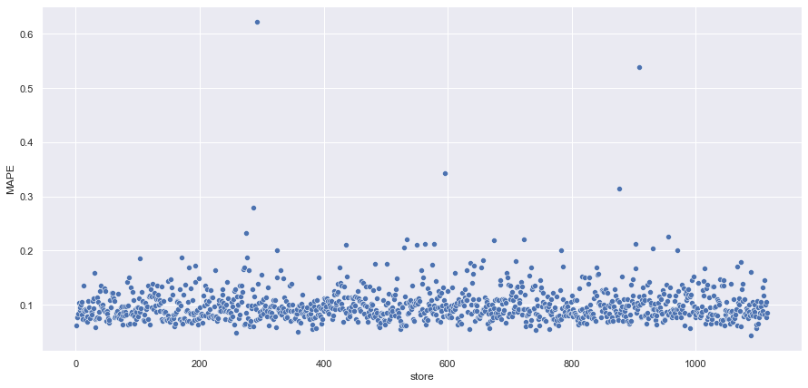

```python
#plot error values (MAPE)
plt.figure(figsize = (15,7))
sns.scatterplot(x = 'store',y = 'MAPE', data = df92)

#Print worst MAPE values
print(df92.sort_values("MAPE", ascending = False).head(10))
```

## 9.2. Total Performance

```python
#Future scenario: Total sales for all stores in 6 weeks
df93 = df92[['predictions','worst_scenario','best_scenario']].apply(lambda x: np.sum(x), axis = 0).reset_index().rename(columns = {"index":"Scenario",0:"Values"})

df93['Values'] = df93['Values'].map("R${:,.2f}".format)
df93
```

|  | Scenario | Values |
| --- | --- | --- |
| 0 | predictions | R$274,491,008.00 |
| 1 | worst_scenario | R$273,720,961.02 |
| 2 | best_scenario | R$275,261,088.56 |

## 9.3. Machine Learning Performance

```python
#plot errors
df9['error'] = df9['sales'] - df9['predictions']
df9['error_rate'] = df9['predictions'] / df9['sales']
```

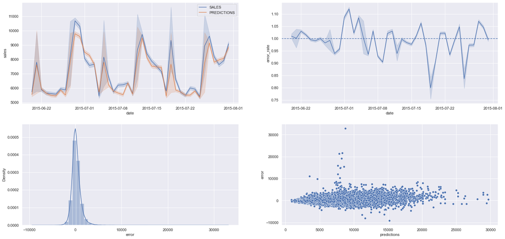

```python
#predictions x real values
plt.subplot( 2, 2, 1 )
sns.lineplot( x='date', y='sales', data=df9, label='SALES' )
sns.lineplot( x='date', y='predictions', data=df9, label='PREDICTIONS' )

#overestimation and underestimation of the real values
plt.subplot( 2, 2, 2 )
sns.lineplot( x='date', y='error_rate', data=df9 )
plt.axhline( 1, linestyle='--')

#error distribution
plt.subplot( 2, 2, 3 )
sns.distplot( df9['error'] )

#residuals
plt.subplot( 2, 2, 4 )
sns.scatterplot( df9['predictions'], df9['error'] )
```

# 10.0. DEPLOY MODEL TO PRODUCTION

```python
#Save Trained Model
pickle.dump(model_xgb_tuned, open("http://localhost:8889/tree/Cecilia/model_rossmann.pkl", 'wb'))
```

## 10.1. Rossmann Class

```python
import pickle
import inflection
import pandas as pd
import numpy as np
import math
import datetime

class Rossmann( object ):
    def __init__( self ):
        self.home_path='/home/cecilia/repos/portifolio/Rossmann_Challenge/'
        self.competition_distance_scaler   = pickle.load( open( self.home_path + 'parameter/competition_distance_scaler.pkl', 'rb') )
        self.competition_time_month_scaler = pickle.load( open( self.home_path + 'parameter/competition_time_month_scaler.pkl', 'rb') )
        self.promo_time_week_scaler        = pickle.load( open( self.home_path + 'parameter/promo_time_week_scaler.pkl', 'rb') )
        self.year_scaler                   = pickle.load( open( self.home_path + 'parameter/year_scaler.pkl', 'rb') )
        self.store_type_scaler             = pickle.load( open( self.home_path + 'parameter/store_type_scaler.pkl', 'rb') )


    def data_cleaning( self, df1 ):

        ## 1.1. Rename Columns
        cols_old = ['Store', 'DayOfWeek', 'Date', 'Open', 'Promo', 'StateHoliday', 'SchoolHoliday',
                    'StoreType', 'Assortment', 'CompetitionDistance', 'CompetitionOpenSinceMonth',
                    'CompetitionOpenSinceYear', 'Promo2', 'Promo2SinceWeek', 'Promo2SinceYear', 'PromoInterval']

        snakecase = lambda x: inflection.underscore( x )

        cols_new = list( map( snakecase, cols_old ) )

        # rename
        df1.columns = cols_new

        ## 1.3. Data Types
        df1['date'] = pd.to_datetime( df1['date'] )

        ## 1.5. Fillout NA
        #competition_distance
        df1['competition_distance'] = df1['competition_distance'].apply( lambda x: 200000.0 if math.isnan( x ) else x )

        #competition_open_since_month
        df1['competition_open_since_month'] = df1.apply( lambda x: x['date'].month if math.isnan( x['competition_open_since_month'] ) else x['competition_open_since_month'], axis=1 )

        #competition_open_since_year
        df1['competition_open_since_year'] = df1.apply( lambda x: x['date'].year if math.isnan( x['competition_open_since_year'] ) else x['competition_open_since_year'], axis=1 )

        #promo2_since_week
        df1['promo2_since_week'] = df1.apply( lambda x: x['date'].week if math.isnan( x['promo2_since_week'] ) else x['promo2_since_week'], axis=1 )

        #promo2_since_year
        df1['promo2_since_year'] = df1.apply( lambda x: x['date'].year if math.isnan( x['promo2_since_year'] ) else x['promo2_since_year'], axis=1 )

        #promo_interval
        month_map = {1: 'Jan',  2: 'Fev',  3: 'Mar',  4: 'Apr',  5: 'May',  6: 'Jun',  7: 'Jul',  8: 'Aug',  9: 'Sep',  10: 'Oct', 11: 'Nov', 12: 'Dec'}

        df1['promo_interval'].fillna(0, inplace=True )

        df1['month_map'] = df1['date'].dt.month.map( month_map )

        df1['is_promo'] = df1[['promo_interval', 'month_map']].apply( lambda x: 0 if x['promo_interval'] == 0 else 1 if x['month_map'] in x['promo_interval'].split( ',' ) else 0, axis=1 )

        ## 1.6. Change Data Types
        # competiton
        df1['competition_open_since_month'] = df1['competition_open_since_month'].astype( int )
        df1['competition_open_since_year'] = df1['competition_open_since_year'].astype( int )

        # promo2
        df1['promo2_since_week'] = df1['promo2_since_week'].astype( int )
        df1['promo2_since_year'] = df1['promo2_since_year'].astype( int )

        return df1


    def feature_engineering( self, df2 ):

        # year
        df2['year'] = df2['date'].dt.year

        # month
        df2['month'] = df2['date'].dt.month

        # day
        df2['day'] = df2['date'].dt.day

        # week of year
        df2['week_of_year'] = df2['date'].dt.weekofyear

        # year week
        df2['year_week'] = df2['date'].dt.strftime( '%Y-%W' )

        # competition since
        df2['competition_since'] = df2.apply( lambda x: datetime.datetime( year=x['competition_open_since_year'], month=x['competition_open_since_month'],day=1 ), axis=1 )
        df2['competition_time_month'] = ( ( df2['date'] - df2['competition_since'] )/30 ).apply( lambda x: x.days ).astype( int )

        # promo since
        df2['promo_since'] = df2['promo2_since_year'].astype( str ) + '-' + df2['promo2_since_week'].astype( str )
        df2['promo_since'] = df2['promo_since'].apply( lambda x: datetime.datetime.strptime( x + '-1', '%Y-%W-%w' ) - datetime.timedelta( days=7 ) )
        df2['promo_time_week'] = ( ( df2['date'] - df2['promo_since'] )/7 ).apply( lambda x: x.days ).astype( int )

        # assortment
        df2['assortment'] = df2['assortment'].apply( lambda x: 'basic' if x == 'a' else 'extra' if x == 'b' else 'extended' )

        # state holiday
        df2['state_holiday'] = df2['state_holiday'].apply( lambda x: 'public_holiday' if x == 'a' else 'easter_holiday' if x == 'b' else 'christmas' if x == 'c' else 'regular_day' )

        # 3.0. PASSO 03 - FILTRAGEM DE VARIÁVEIS
        ## 3.1. Filtragem das Linhas
        df2 = df2[df2['open'] != 0]

        ## 3.2. Selecao das Colunas
        cols_drop = ['open', 'promo_interval', 'month_map']
        df2 = df2.drop( cols_drop, axis=1 )

        return df2


    def data_preparation( self, df5 ):

        ## 5.2. Rescaling
        # competition distance
        df5['competition_distance'] = self.competition_distance_scaler.fit_transform( df5[['competition_distance']].values )

        # competition time month
        df5['competition_time_month'] = self.competition_time_month_scaler.fit_transform( df5[['competition_time_month']].values )

        # promo time week
        df5['promo_time_week'] = self.promo_time_week_scaler.fit_transform( df5[['promo_time_week']].values )

        # year
        df5['year'] = self.year_scaler.fit_transform( df5[['year']].values )

        ### 5.3.1. Encoding
        # state_holiday - One Hot Encoding
        df5 = pd.get_dummies( df5, prefix=['state_holiday'], columns=['state_holiday'] )

        # store_type - Label Encoding
        df5['store_type'] = self.store_type_scaler.fit_transform( df5['store_type'] )

        # assortment - Ordinal Encoding
        assortment_dict = {'basic': 1,  'extra': 2, 'extended': 3}
        df5['assortment'] = df5['assortment'].map( assortment_dict )


        ### 5.3.3. Nature Transformation
        # day of week
        df5['day_of_week_sin'] = df5['day_of_week'].apply( lambda x: np.sin( x * ( 2. * np.pi/7 ) ) )
        df5['day_of_week_cos'] = df5['day_of_week'].apply( lambda x: np.cos( x * ( 2. * np.pi/7 ) ) )

        # month
        df5['month_sin'] = df5['month'].apply( lambda x: np.sin( x * ( 2. * np.pi/12 ) ) )
        df5['month_cos'] = df5['month'].apply( lambda x: np.cos( x * ( 2. * np.pi/12 ) ) )

        # day
        df5['day_sin'] = df5['day'].apply( lambda x: np.sin( x * ( 2. * np.pi/30 ) ) )
        df5['day_cos'] = df5['day'].apply( lambda x: np.cos( x * ( 2. * np.pi/30 ) ) )

        # week of year
        df5['week_of_year_sin'] = df5['week_of_year'].apply( lambda x: np.sin( x * ( 2. * np.pi/52 ) ) )
        df5['week_of_year_cos'] = df5['week_of_year'].apply( lambda x: np.cos( x * ( 2. * np.pi/52 ) ) )


        cols_selected = ['store',
                        'promo',
                        'store_type',
                        'assortment',
                        'competition_distance',
                        'competition_open_since_month',
                        'competition_open_since_year',
                        'promo2','promo2_since_week',
                        'promo2_since_year',
                        'competition_time_month',
                        'promo_time_week',
                        'day_of_week_sin',
                        'day_of_week_cos',
                        'month_cos',
                        'month_sin',
                        'day_sin',
                        'day_cos',
                        'week_of_year_cos',
                        'week_of_year_sin']

        return df5[ cols_selected ]


    def get_prediction( self, model, original_data, test_data ):
        # prediction
        pred = model.predict( test_data )

        # join pred into the original data
        original_data['prediction'] = np.expm1( pred )

        return original_data.to_json( orient='records', date_format='iso' )
```

## 10.2. API Handler

```python
import pickle
import pandas as pd
from flask             import Flask, request, Response
from rossmann.Rossmann import Rossmann

# loading model
model = pickle.load( open( '/home/cecilia/repos/portifolio/Rossmann_Challenge/model/model_rossmann.pkl', 'rb') )

# initialize API
app = Flask( __name__ )

@app.route( '/rossmann/predict', methods=['POST'] )
def rossmann_predict():
    test_json = request.get_json()

    if test_json: # there is data
        if isinstance( test_json, dict ): # unique example
            test_raw = pd.DataFrame( test_json, index=[0] )

        else: # multiple example
            test_raw = pd.DataFrame( test_json, columns=test_json[0].keys() )

        # Instantiate Rossmann class
        pipeline = Rossmann()

        # data cleaning
        df1 = pipeline.data_cleaning( test_raw )

        # feature engineering
        df2 = pipeline.feature_engineering( df1 )

        # data preparation
        df3 = pipeline.data_preparation( df2 )

        # prediction
        df_response = pipeline.get_prediction( model, test_raw, df3 )

        return df_response


    else:
        return Reponse( '{}', status=200, mimetype='application/json' )

if __name__ == '__main__':
    app.run( '0.0.0.0' )
```

## 10.3. API Tester

```python
# loading test dataset
df10 = pd.read_csv( '/home/cecilia/repos/portifolio/Rossmann_Challenge/data/test.csv' )
```

```python
# merge test dataset + store
df_test = pd.merge( df10, df_store_raw, how='left', on='Store' )

# choose store for prediction
df_test = df_test[df_test['Store'].isin( [30, 24, 25] )]

# remove closed days
df_test = df_test[df_test['Open'] != 0]
df_test = df_test[~df_test['Open'].isnull()]
df_test = df_test.drop( 'Id', axis=1 )
```

```python
# convert Dataframe to json
data = json.dumps( df_test.to_dict( orient='records' ) )
```

```python
# API Call
#url = 'http://0.0.0.0:5000/rossmann/predict'
url = 'https://rossmann-deploy.herokuapp.com/rossmann/predict'
header = {'Content-type': 'application/json' }
data = data

r = requests.post( url, data=data, headers=header )
print( 'Status Code {}'.format( r.status_code ) )
```

```
Status Code 200
```

```python
d1 = pd.DataFrame( r.json(), columns=r.json()[0].keys() )
```

```python
d2 = d1[['store', 'prediction']].groupby( 'store' ).sum().reset_index()

for i in range( len( d2 ) ):
    print( 'Store Number {} will sell R${:,.2f} in the next 6 weeks'.format(
            d2.loc[i, 'store'],
            d2.loc[i, 'prediction'] ) )
```

```
Store Number 24 will sell R$368,941.47 in the next 6 weeks
Store Number 25 will sell R$401,799.78 in the next 6 weeks
Store Number 30 will sell R$192,683.12 in the next 6 weeks
```